# Assignment - 2

Shrutika Potdar

11/4/2019

## GitHub User Description

The GitHub user that I have analyzed is Yichun Zhang with profile name agentzh. Yichun is the Creator of OpenResty, Founder & CEO of OpenResty Inc. based in San Francisco. Yichun has 64 repositories and 9604 followers to be precise. Yichun’s github page url is: https://github.com/agentzh

## Import all the required packages and libraries

```r
#install.packages("foreach")
#install.packages("dplyr")
#install.packages(c("httr", "devtools"))
#install.packages("kableExtra")
library(kableExtra)
library(tidyverse)
library(dplyr)
library(plyr)
library(httr)
library(gh)
library(repurrrsive)
library(jsonlite)
library(doParallel)
library(foreach)
library(lubridate)
```

```r
library(ggplot2)
library(purrr)
```

## Setup the GitHub Token

```r
rm(list=ls())
options(encoding="UTF-8")

my_token = "60a2fb831c0fdf8e5068fa30d01bb451f33b5fc3" # github personal token
Sys.setenv(GITHUB_TOKEN = my_token)
```

## Extract Repos of GitHub user

```r
user_repos_list = gh("/users/agentzh/repos",.limit = Inf)
repo <- dir.create(file.path("repo"), recursive = TRUE)
```

```r
path <- "./repo/"
files <- dir(path, pattern = "*.json")

# Iterate through the json_array elements and save them in a file
for(i in 1:length(user_repos_list)) {
  Export_json = toJSON(user_repos_list[i])
  write(Export_json,paste(path, "repos_", user_repos_list[[i]][3], ".json", sep=""))
}

#Load Repos to df
files = dir(path, pattern = "*.json")
files = files %>% file.path(path,.)
repo_df <- files %>%
  map_df(~fromJSON(., flatten = TRUE))
```

## Github User’s Followers Details

```r
followers_list = gh("/users/agentzh/followers",.limit = Inf)
follower <- dir.create(file.path("follower"), recursive = TRUE)
```

```r
followers_path <- "./follower/"
followers_files <- dir(path, pattern = "*.json")

# Iterate through the json_array elements and save them in a file
for(i in 1:length(followers_list)) {
  Export_json = toJSON(followers_list[i],pretty = TRUE)
  write(Export_json,paste(followers_path,"followers_",followers_list[[i]][1],".json",sep=""))
}

#Read followers json file to dataframe
followers_files = dir(followers_path, pattern = "*.json")
followers_files = followers_files %>% file.path(followers_path,.)

followers_df = followers_files %>% map_df(.,~fromJSON(., flatten = TRUE))
```

## Issues of User’s each repos

```r
issue <- dir.create(file.path("issue"), recursive = TRUE)
issues_path <- "./issue/"
for(i in 1:length(user_repos_list)){
  if (user_repos_list[[i]]$has_issues) {
    issue_url = paste("/repos/agentzh/",user_repos_list[[i]]$name,"/issues",sep="")
    issue_list = gh(issue_url, .limit = Inf, state= "all")
    Export_json = toJSON(issue_list,pretty = TRUE)
    write(Export_json,paste(issues_path,"issue_",user_repos_list[[i]][3],".json",sep=""))
  }
}

#Reading Issues
issues_files <- dir(issues_path, pattern = "*.json")
issues_files = issues_files %>% file.path(issues_path,.)
issues = list()
for(i in 1:length(issues_files)) {
  df = fromJSON(issues_files[[i]], flatten = TRUE)
  if (!df[1,1]==""){
    issues[[i]] = df
  }
}

removed_issues = bind_rows(issues)

issues_df = as_tibble(removed_issues)
```

## Describing User

```r
user = gh("/users/agentzh")
json_text = toJSON(user)

users_df_new = fromJSON(json_text, flatten = TRUE)

table_user_df <- ldply (users_df_new, data.frame)

df_agentzh <- tibble(user_name = user$name, user_login = user$login,
                     user_id = user$id, public_repos = user$public_repos,
                     followers = user$followers,
                     date_created = as.Date(user$created_at))
kable(head(df_agentzh))
```

| user_name | user_login | user_id | public_repos | followers | date_created |
| --- | --- | --- | --- | --- | --- |
| Yichun Zhang | agentzh | 56241 | 64 | 9604 | 2009-02-20 |

## Describing Followers

```r
df_agentzh_followers = followers_df %>%
  select(login, id, repos_url,url)

kable(head(df_agentzh_followers))
```

| login | id | repos_url | url |
| --- | --- | --- | --- |
| 06wagon | 13743980 | https://api.github.com/users/06wagon/repos | https://api.github.com/users/06wagon |
| 0704681032 | 3282178 | https://api.github.com/users/0704681032/repos | https://api.github.com/users/0704681032 |
| 09missh | 18696744 | https://api.github.com/users/09missh/repos | https://api.github.com/users/09missh |
| 0chen | 148579 | https://api.github.com/users/0chen/repos | https://api.github.com/users/0chen |
| 0kz | 735693 | https://api.github.com/users/0kz/repos | https://api.github.com/users/0kz |
| 0RaymondJiang0 | 501182 | https://api.github.com/users/0RaymondJiang0/repos | https://api.github.com/users/0RaymondJiang0 |

## Describing Repos

```r
user_repos_df = repo_df %>% select(name,language,size, forks_count, stargazers_count,
                                   watchers_count,open_issues_count)

kable(head(user_repos_df))
```

| name | language | size | forks_count | stargazers_count | watchers_count | open_issues_count |
| --- | --- | --- | --- | --- | --- | --- |
| advent.perlchina.org | Perl | 2065 | 2 | 1 | 1 | 0 |
| agentzh.org | HTML | 176 | 1 | 11 | 11 | 0 |
| aho-corasick-lua | Lua | 139 | 1 | 12 | 12 | 0 |
| amazon-polly-batch | Perl | 13 | 12 | 56 | 56 | 0 |
| appears | C++ | 86 | 2 | 2 | 2 | 0 |
| cheater | Perl | 190 | 18 | 69 | 69 | 3 |

## Describing Issues

```r
#issues_df %>% mutate(created_at = ymd_hms(created_at))

user_issues_df = merge(x = repo_df, y = issues_df, by.x="url",by.y="repository_url",all.x = TRUE, sort=F)

user_issues_df = user_issues_df %>%
  select(name,number,open_issues_count,open_issues,created_at.y,updated_at.y) %>%
  mutate(issue_created_at = ymd_hms(created_at.y),
         issue_updated_at = ymd_hms(updated_at.y)) %>%
  select(name,number,open_issues_count,open_issues,issue_created_at,issue_updated_at)
# date difference is in days
user_issues_df = user_issues_df %>%
  mutate(date_diff = difftime(issue_updated_at, issue_created_at, tz = "EST", units="days")) %>%
  mutate(avg_duration_to_close_issue = mean(date_diff, na.rm=TRUE))

kable(head(user_issues_df))
```

| name | number | open_issues_count | open_issues | issue_created_at | issue_updated_at | date_diff | avg_duration_to_close_issue |
| --- | --- | --- | --- | --- | --- | --- | --- |
| agentzh.org | 1 | 0 | 0 | 1308752873 | 1308884109 | 1.5189352 | 85.96732 |
| amazon-polly-batch | 2 | 0 | 0 | 1522256721 | 1522257237 | 0.0059722 | 85.96732 |
| amazon-polly-batch | 1 | 0 | 0 | 1506531489 | 1522257787 | 182.017338 | 85.96732 |
| cheater | 5 | 3 | 3 | 1326227678 | 1326853975 | 7.2488079 | 85.96732 |
| cheater | 4 | 3 | 3 | 1326165591 | 1326167526 | 0.0223958 | 85.96732 |
| cheater | 3 | 3 | 3 | 1318876505 | 1318900040 | 0.2723958 | 85.96732 |

## Data Visualization

**Visualization #1**

Plot the Distribution of Languages based on User’s Repos

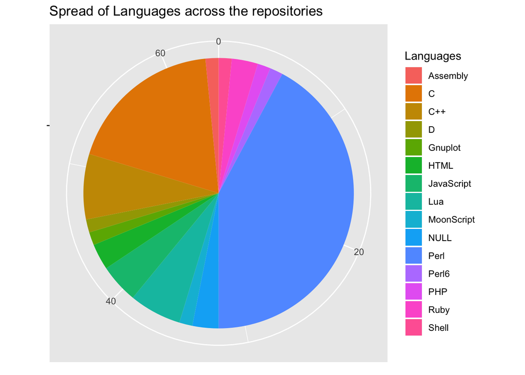

```r
plot_1 <- ggplot(repo_df, aes(x = "", fill = as.character(language))) +
  geom_bar(width = 1) +
  theme(axis.line = element_blank(),
        plot.title = element_text()) +
  labs(fill = "Languages",
       x = NULL,
       y = NULL,
       title = "Spread of Languages across the repositories")

plot_1 + coord_polar(theta = "y", start = 0)
```

**Patterns in the plot**

The pie chart plotted above shows that Perl language is being highly utilized across the various repositories. Thus, this suggests that the user is more inclined towards Perl langauge or is more proficient in Perl followed by C language.

**Visualization #2**

Plot User Repositories based on its size

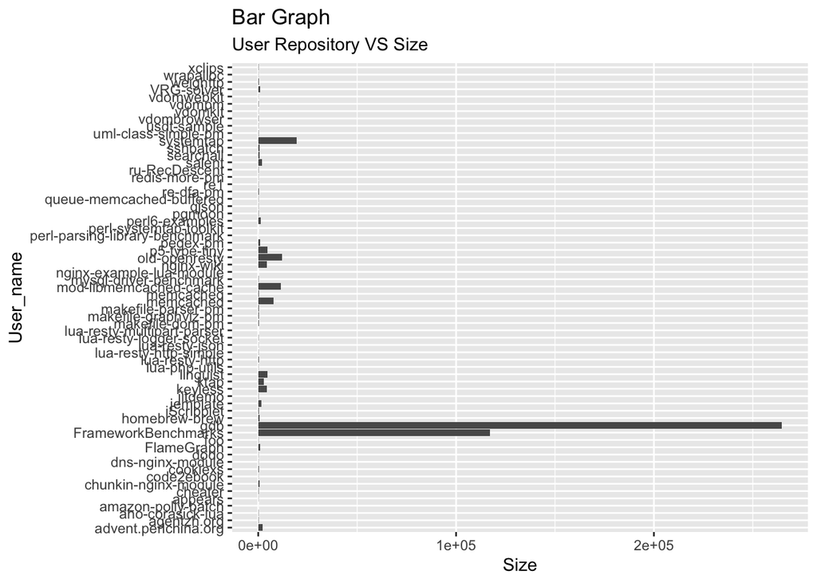

```r
ggplot(data = repo_df, aes(x = as.character(name), y = size)) +
  coord_flip() +
  geom_bar(stat="identity") +
   labs(title="Bar Graph",
       subtitle="User Repository VS Size",
       x="User_name",
       y="Size")
```

**Patterns in the plot**

Here, I have plotted the repositories based on their size. It shows us how large the repos are and we can further analyze it or filter it on basis of language as well.

**Visualization #3**

Plot the bar graph for the number of issues raised by Users

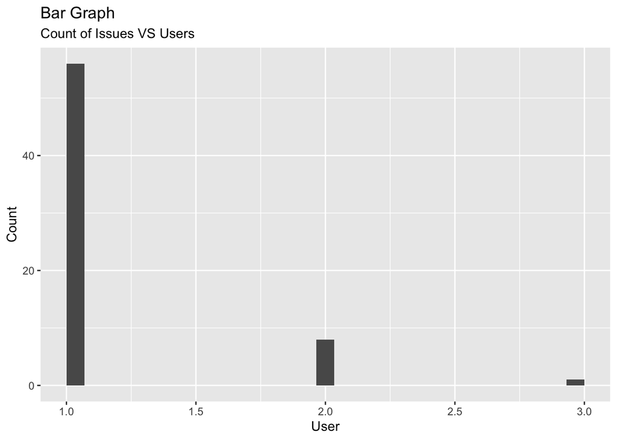

```r
number_of_issues <- issues_df %>%
  group_by(as.integer(user.id),as.character(user.login)) %>%
  summarize(number_issues = count(as.integer(user.id)))

ggplot(data = number_of_issues, aes(x = number_of_issues$number_issues$freq)) +
  stat_bin(bins=30) +
  labs(title="Bar Graph",
       subtitle="Count of Issues VS Users",
       x="User",
       y="Count")
```

**Patterns in the plot**

This plot tell us that number_of_issues is representing the user’s who has raised issues in each repository. We can see that most of the users raised just 1 issues in each repository. This can help us to refer the issues in case we come the same kind of problem.